# Using generative AI with structured data for programmatic SEO

Prompt engineering is one of the hot topics these days, and it is constantly changing due to rapid changes in the guidelines, the underlying technologies’ capabilities, as well as our understanding of them.

It is mostly known as making many attempts, changing, rewriting a prompt, until you find one that works for the task at hand.

I would like to build on this and share a pattern of building prompt **templates** that can be used in bulk, for the creation of product descriptions, email marketing messages, and any other type of content.

The key enabler in this pattern is the availability of strcutured data for many items, and for a consitent set of attributes.

| product | size | color | price |
| --- | --- | --- | --- |
| Product A | 10 | blue | 150 |
| Product B | 12 | green | 180 |
| Product C | 15 | red | 125 |

A very simple prompt for a product description for one of those products can be something like this:

> Please create a product description for **Product A** Mention its size, which is **10** Also mention its color, which is **blue** And talk about its price: **150** The tone of voice should be professional

Now we have several important things to consider: 1. We would like to scale our prompting to encompass all our products. 2. The consistency of our data enables us to run the same process across many products. 3. It would be great if we can save the process that generated our product descriptions. This is in order to debug issues, reproduce them again, and eventually update them by tweaking the prompt or by adding new product attributes whenever we have updated data.

```python
import pandas as pd
products = pd.DataFrame({
    'product': ['Product A', 'Product B', 'Product C'],
    'size': [10, 12, 15],
    'color': ['blue', 'green', 'red'],
    'price': [150, 180, 125]
})
products
```

|  | product | size | color | price |
| --- | --- | --- | --- | --- |
| 0 | Product A | 10 | blue | 150 |
| 1 | Product B | 12 | green | 180 |
| 2 | Product C | 15 | red | 125 |

## Creating prompts in bulk

For our simple product dataset, we can create a simple for-loop that goes through the products and dynamically inserts the product’s attributes to the prompt:

```python
prompt_template = """
Please create a product description for {product}.
Mention its size, which is {size}
Also mention its color, which is {color}
Talk about its price: {price}
The tone of voice should be professional
"""

for row in products.to_dict('records'):
    print(prompt_template.format_map(row))
```

```
Please create a product description for Product A.
Mention its size, which is 10
Also mention its color, which is blue
Talk about its price: 150
The tone of voice should be professional


Please create a product description for Product B.
Mention its size, which is 12
Also mention its color, which is green
Talk about its price: 180
The tone of voice should be professional


Please create a product description for Product C.
Mention its size, which is 15
Also mention its color, which is red
Talk about its price: 125
The tone of voice should be professional
```

Let’s take a quick look at some of the adavantages of this approach:

## Reproducibility

Eventually we will most likely want to update those descriptions. Obviously this is not a good prompt, doesn’t provide much context, and can be improved in many ways. We might have a new SEO strategy and want to focus on other aspects of our products. We might get new data, like user ratings for example, and might want to incorporate a new line in our prompt, and so on.

## Scaling

I think this is obvious. This approach clearly allows us to create descriptions on a large scale, provided we have consitent data, and that the items are similar (belonging to the same product category, or are of the same type).

## Minimizing hallucinations

Trusting LLMs to create product descriptions for you is risky business, because they are well-known for how easily they can invent “facts”, and also being “confident” about them. With this approach, we are restricting the factual information to the data that we provide, and we are also utilizing the great language processing capabilities of LLMs. We can also explicitly mention in the prmopt something like, “only use the data provided.”

Now that we have clarified the approach and its benefits, let’s see how this might be used in a real-life situation.

## How to use LLMs for product descriptions on a large scale

The example I will go through is for NBAstats.pro a website for [NBA player statistics](https://nbastats.pro) as the name suggests. It’s an experimental project for testing this approach and seeing how useful it can be for users, and how it might rank on search. We will connect to the NBA data API, obtain career data for each player (per season and per metric), and use that to create profile pages for each player. The main keyword template we are targeting here is “<player_name> stats”.

## Added value of using LLMs for product descriptions

What we are doing here is not a simple re-arrangement of what someone else wrote and calling it our own. This would not add real value, and would not be an ethical thing to do. We are using publicly available data to uncover some insights, and with those facts creating an interesting description. This description should make the reader better informed about the topic discussed in two main ways:

### Insights

With the availability of structured data about our players, we can make some calculations, and uncover some interesting facts that might not be immediately visible from the raw data. For example, the raw data show how many points they scored every season, as well as how games they played. We can easily calculate the points per game and provide more insight than what the simple data might suggest. We can take this further by taking those totals or averages, and comparing them to all other players in the NBA, “Player A scored a total of X points in his career, putting him in the top Z players of all time.”

### Charts

Another added value we can add to the raw data is that we can visualize the data for truly more insightful perspectives into the players’ careers. We are targeting who are specifically searching for player stats, and they would most likely appreciate more insights into those stats through some visualizations.

How easy is it to understand [Michael Jordan’s career stats](https://nbastats.pro/player/Michael_Jordan) by looking at this table?

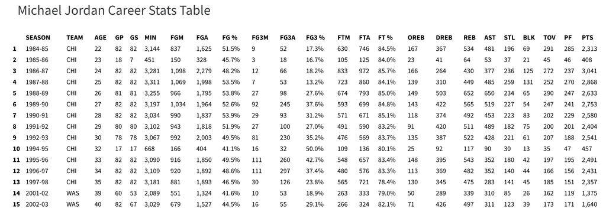

Maybe this is better:

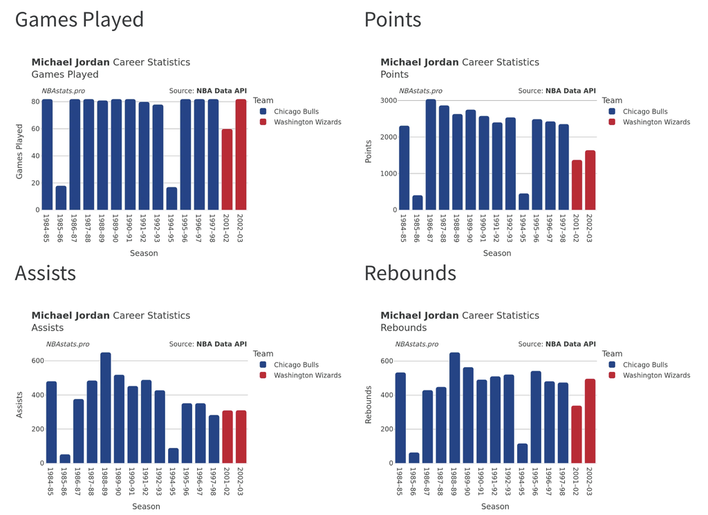

Was it easy for you to spot the two seasons where he played a very low number of games, and that otherwise he played pretty much all games of all seasons?

Of course those charts are not produced by the LLM. We will produce them with Plotly, a Python data visualization library, and of course we can use other libraries for that.

From an SEO perspective we are also producing a lot of image assets which might hopefully also rank on image search for related terms. In this website, we have 8 charts per player, which is almost forty thousand charts in total. This is real content based on actual data, and we are using it to provide additional insights to our users.

## Creating prompt templates

Just like what we did with the toy example above, we will now create a prompt template for NBA players.

### Importing libraries

```python
import pandas as pd
from openai import OpenAI
from nba_api.stats.endpoints import playercareerstats
from nba_api.stats.static import players, teams
import plotly.express as px
pd.options.display.max_columns = None
import os
from IPython.display import display_markdown
def md(text):
    return display_markdown(text, raw=True)
client = OpenAI(api_key=os.environ['OPENAI_API_KEY'])
```

## Getting static data about players and teams (ID’s, full name, city, state, etc.)

These are two fairly stable datasets containing simple high-level data on players and teams.

```python
players_static = players.get_players()
```

```python
pd.DataFrame(players_static).to_csv('players_static.csv', index=False)
```

```python
teams_static = teams.get_teams()
```

```python
pd.DataFrame(teams_static).to_csv('teams_static.csv', index=False)
```

```python
players_static = pd.read_csv('players_static.csv')
teams_static = pd.read_csv('teams_static.csv')
```

```python
players_static.sample(10)
```

|  | id | full_name | first_name | last_name | is_active |
| --- | --- | --- | --- | --- | --- |
| 3393 | 77825 | George Pearcy | George | Pearcy | False |
| 1849 | 1538 | Cedric Henderson | Cedric | Henderson | False |
| 4077 | 22 | Rik Smits | Rik | Smits | False |
| 2829 | 77517 | Paul McCracken | Paul | McCracken | False |
| 3022 | 600006 | Earl Monroe | Earl | Monroe | False |
| 4324 | 78340 | Mel Thurston | Mel | Thurston | False |
| 3460 | 2565 | Zoran Planinic | Zoran | Planinic | False |
| 1782 | 203914 | Gary Harris | Gary | Harris | True |
| 42 | 203128 | Furkan Aldemir | Furkan | Aldemir | False |
| 1094 | 76577 | Terry Dischinger | Terry | Dischinger | False |

```python
teams_static.sample(10)
```

|  | id | full_name | abbreviation | nickname | city | state | year_founded |
| --- | --- | --- | --- | --- | --- | --- | --- |
| 13 | 1610612750 | Minnesota Timberwolves | MIN | Timberwolves | Minnesota | Minnesota | 1989 |
| 15 | 1610612752 | New York Knicks | NYK | Knicks | New York | New York | 1946 |
| 27 | 1610612764 | Washington Wizards | WAS | Wizards | Washington | District of Columbia | 1961 |
| 21 | 1610612758 | Sacramento Kings | SAC | Kings | Sacramento | California | 1948 |
| 6 | 1610612743 | Denver Nuggets | DEN | Nuggets | Denver | Colorado | 1976 |
| 9 | 1610612746 | Los Angeles Clippers | LAC | Clippers | Los Angeles | California | 1970 |
| 19 | 1610612756 | Phoenix Suns | PHX | Suns | Phoenix | Arizona | 1968 |
| 14 | 1610612751 | Brooklyn Nets | BKN | Nets | Brooklyn | New York | 1976 |
| 3 | 1610612740 | New Orleans Pelicans | NOP | Pelicans | New Orleans | Louisiana | 2002 |
| 1 | 1610612738 | Boston Celtics | BOS | Celtics | Boston | Massachusetts | 1946 |

```python
players_static[players_static['full_name'].isin(['LeBron James', 'Michael Jordan'])]
```

|  | id | full_name | first_name | last_name | is_active |
| --- | --- | --- | --- | --- | --- |
| 2111 | 2544 | LeBron James | LeBron | James | True |
| 2291 | 893 | Michael Jordan | Michael | Jordan | False |

## Get player career stats using the player’s ID

The `playercareerstats` endpoint is responsible for providing all the data for each player. For this we need the player’s ID which we can get from the previously obrained `players_static` table.

```python
lebron_james = playercareerstats.PlayerCareerStats(player_id=2544)
michael_jordan = playercareerstats.PlayerCareerStats(player_id=893)
```

```python
lebron_james.get_data_frames()[0].head()
```

|  | PLAYER_ID | SEASON_ID | LEAGUE_ID | TEAM_ID | TEAM_ABBREVIATION | PLAYER_AGE | GP | GS | MIN | FGM | FGA | FG_PCT | FG3M | FG3A | FG3_PCT | FTM | FTA | FT_PCT | OREB | DREB | REB | AST | STL | BLK | TOV | PF | PTS |
| --- | --- | --- | --- | --- | --- | --- | --- | --- | --- | --- | --- | --- | --- | --- | --- | --- | --- | --- | --- | --- | --- | --- | --- | --- | --- | --- | --- |
| 0 | 2544 | 2003-04 | 00 | 1610612739 | CLE | 19.0 | 79 | 79 | 3120.0 | 622 | 1492 | 0.417 | 63 | 217 | 0.290 | 347 | 460 | 0.754 | 99 | 333 | 432 | 465 | 130 | 58 | 273 | 149 | 1654 |
| 1 | 2544 | 2004-05 | 00 | 1610612739 | CLE | 20.0 | 80 | 80 | 3388.0 | 795 | 1684 | 0.472 | 108 | 308 | 0.351 | 477 | 636 | 0.750 | 111 | 477 | 588 | 577 | 177 | 52 | 262 | 146 | 2175 |
| 2 | 2544 | 2005-06 | 00 | 1610612739 | CLE | 21.0 | 79 | 79 | 3361.0 | 875 | 1823 | 0.480 | 127 | 379 | 0.335 | 601 | 814 | 0.738 | 75 | 481 | 556 | 521 | 123 | 66 | 260 | 181 | 2478 |
| 3 | 2544 | 2006-07 | 00 | 1610612739 | CLE | 22.0 | 78 | 78 | 3190.0 | 772 | 1621 | 0.476 | 99 | 310 | 0.319 | 489 | 701 | 0.698 | 83 | 443 | 526 | 470 | 125 | 55 | 250 | 171 | 2132 |
| 4 | 2544 | 2007-08 | 00 | 1610612739 | CLE | 23.0 | 75 | 74 | 3027.0 | 794 | 1642 | 0.484 | 113 | 359 | 0.315 | 549 | 771 | 0.712 | 133 | 459 | 592 | 539 | 138 | 81 | 255 | 165 | 2250 |

```python
michael_jordan.get_data_frames()[0].head()
```

|  | PLAYER_ID | SEASON_ID | LEAGUE_ID | TEAM_ID | TEAM_ABBREVIATION | PLAYER_AGE | GP | GS | MIN | FGM | FGA | FG_PCT | FG3M | FG3A | FG3_PCT | FTM | FTA | FT_PCT | OREB | DREB | REB | AST | STL | BLK | TOV | PF | PTS |
| --- | --- | --- | --- | --- | --- | --- | --- | --- | --- | --- | --- | --- | --- | --- | --- | --- | --- | --- | --- | --- | --- | --- | --- | --- | --- | --- | --- |
| 0 | 893 | 1984-85 | 00 | 1610612741 | CHI | 22.0 | 82 | 82 | 3144.0 | 837 | 1625 | 0.515 | 9 | 52 | 0.173 | 630 | 746 | 0.845 | 167 | 367 | 534 | 481 | 196 | 69 | 291 | 285 | 2313 |
| 1 | 893 | 1985-86 | 00 | 1610612741 | CHI | 23.0 | 18 | 7 | 451.0 | 150 | 328 | 0.457 | 3 | 18 | 0.167 | 105 | 125 | 0.840 | 23 | 41 | 64 | 53 | 37 | 21 | 45 | 46 | 408 |
| 2 | 893 | 1986-87 | 00 | 1610612741 | CHI | 24.0 | 82 | 82 | 3281.0 | 1098 | 2279 | 0.482 | 12 | 66 | 0.182 | 833 | 972 | 0.857 | 166 | 264 | 430 | 377 | 236 | 125 | 272 | 237 | 3041 |
| 3 | 893 | 1987-88 | 00 | 1610612741 | CHI | 25.0 | 82 | 82 | 3311.0 | 1069 | 1998 | 0.535 | 7 | 53 | 0.132 | 723 | 860 | 0.841 | 139 | 310 | 449 | 485 | 259 | 131 | 252 | 270 | 2868 |
| 4 | 893 | 1988-89 | 00 | 1610612741 | CHI | 26.0 | 81 | 81 | 3255.0 | 966 | 1795 | 0.538 | 27 | 98 | 0.276 | 674 | 793 | 0.850 | 149 | 503 | 652 | 650 | 234 | 65 | 290 | 247 | 2633 |

## Create a prompt template and dynamically insert each player’s data

Just like we did with the simple prompt template above, we can do the exact same thing we did above. Note that since we have more data and of different types, the loop is not as straighforward. For example for most columns we get the sum of the column to get the player’s career stats for that metric (games played, steals, blocks, etc.). In some cases, like seasons played, and teams played for, it doesn’t make sense to sum these values.

```python
responses = []
for player_id in [2544, 893, 203999, 76003]:
    player_stats_df = playercareerstats.PlayerCareerStats(player_id=player_id).get_data_frames()[0]
    player_stats_df = pd.merge(
        player_stats_df,
        players_static,
        left_on='PLAYER_ID',
        right_on='id',
        how='left')
    player_stats_df = pd.merge(
        player_stats_df,
        teams_static,
        left_on='TEAM_ID',
        right_on='id',
        how='left')
    display(player_stats_df)

    # player_id = int(player_id.replace('player_', '').replace('.csv', ''))
    # t0 = time.time()
    try:
        df = player_stats_df[player_stats_df['PLAYER_ID'].eq(player_id)]
        if (df['FGM'].sum() > 0) and  (df['FGA'].sum() > 0):
            goals_percent = df['FGM'].sum() / df['FGA'].sum()
        else:
            goals_percent = 'unknown'
        if (df['FTM'].sum() > 0) and (df['FTA'].sum() > 0):
            freethrows_percent = df['FTM'].sum() / df['FTA'].sum() > 0
        else:
            freethrows_percent = 'unknown'
        d = dict(
            name = df['full_name_x'].iloc[0],
            teams = df['full_name_y'].drop_duplicates().dropna().tolist(),
            cities = df['city'].drop_duplicates().dropna().tolist(),
            states = df['state'].drop_duplicates().dropna().tolist(),
            active = df['is_active'].iloc[-1],
            start_season = df['SEASON_ID'].iloc[0],
            end_season = df['SEASON_ID'].iloc[-1],
            start_age = df['PLAYER_AGE'].iloc[0],
            end_age = df['PLAYER_AGE'].iloc[-1],
            games_played = df['GP'].sum(),
            minutes_played = df['MIN'].sum(),
            goals_attempted = df['FGA'].sum(),
            goals_made = df['FGM'].sum(),
            goals_percent = goals_percent,
            freethrows_attempted = df['FTA'].sum(),
            freethrows_made = df['FTM'].sum(),
            freethrows_percent = freethrows_percent,
            rebounds = df['REB'].sum(),
            rebounds_def = df['DREB'].sum(),
            rebounds_off = df['OREB'].sum(),
            assists = df['AST'].sum(),
            steals = df['STL'].sum(),
            blocks = df['BLK'].sum(),
            points = df['PTS'].sum(),
    )
        prompt = [
            {"role": "system",
             "content": """
You are a smart, detail-oriencted, keen NBA Basketball player analyst.
Please write an introductory text for a profile page of this Basketball player.
Length: 500 - 800 words.
please stick to the stats provided.
Tone: should be interesting factual intriguing and inviting the user to dive
into the charts on the page to better get to know the player."""},
             {"role": "user",
              "content": f"""
Please write and article for the player using the following details:
{d}"""}]
        display(md(f"## {df['full_name_x'].iloc[0]}"))
        for k, v in prompt[0].items():
            print(k, v)
        print()
        for k, v in d.items():
            print(k, v)
    except Exception as e:
        print(str(e))
        continue
    completion = client.chat.completions.create(
      # model="gpt-4o",
      model="gpt-3.5-turbo",
      messages=[
        {"role": "system",
         "content": """You are a smart, detail-oriencted, keen NBA Basketball player analyst. \
         Please write an introductory text for a profile page of this Basketball player.
         Length: 500 - 800 words.
         please stick to the stats provided.
         Tone: should be interesting factual intriguing and inviting the user to dive \
         into the charts on the page to better get to know the player.
         """},
        {"role": "user",
         "content": f"""Please write and article for the player using the following details:
         {d}
         """}
      ]
    )
    responses.append([player_id, completion])
    print()
    print(completion.dict()['choices'][0]['message']['content'])
    print()
    display(md('----'))
```

|  | PLAYER_ID | SEASON_ID | LEAGUE_ID | TEAM_ID | TEAM_ABBREVIATION | PLAYER_AGE | GP | GS | MIN | FGM | FGA | FG_PCT | FG3M | FG3A | FG3_PCT | FTM | FTA | FT_PCT | OREB | DREB | REB | AST | STL | BLK | TOV | PF | PTS | id_x | full_name_x | … |
| --- | --- | --- | --- | --- | --- | --- | --- | --- | --- | --- | --- | --- | --- | --- | --- | --- | --- | --- | --- | --- | --- | --- | --- | --- | --- | --- | --- | --- | --- | --- |
| 0 | 2544 | 2003-04 | 00 | 1610612739 | CLE | 19.0 | 79 | 79 | 3120.0 | 622 | 1492 | 0.417 | 63 | 217 | 0.290 | 347 | 460 | 0.754 | 99 | 333 | 432 | 465 | 130 | 58 | 273 | 149 | 1654 | 2544 | LeBron James | … |
| 1 | 2544 | 2004-05 | 00 | 1610612739 | CLE | 20.0 | 80 | 80 | 3388.0 | 795 | 1684 | 0.472 | 108 | 308 | 0.351 | 477 | 636 | 0.750 | 111 | 477 | 588 | 577 | 177 | 52 | 262 | 146 | 2175 | 2544 | LeBron James | … |
| 2 | 2544 | 2005-06 | 00 | 1610612739 | CLE | 21.0 | 79 | 79 | 3361.0 | 875 | 1823 | 0.480 | 127 | 379 | 0.335 | 601 | 814 | 0.738 | 75 | 481 | 556 | 521 | 123 | 66 | 260 | 181 | 2478 | 2544 | LeBron James | … |
| 3 | 2544 | 2006-07 | 00 | 1610612739 | CLE | 22.0 | 78 | 78 | 3190.0 | 772 | 1621 | 0.476 | 99 | 310 | 0.319 | 489 | 701 | 0.698 | 83 | 443 | 526 | 470 | 125 | 55 | 250 | 171 | 2132 | 2544 | LeBron James | … |
| 4 | 2544 | 2007-08 | 00 | 1610612739 | CLE | 23.0 | 75 | 74 | 3027.0 | 794 | 1642 | 0.484 | 113 | 359 | 0.315 | 549 | 771 | 0.712 | 133 | 459 | 592 | 539 | 138 | 81 | 255 | 165 | 2250 | 2544 | LeBron James | … |
| 5 | 2544 | 2008-09 | 00 | 1610612739 | CLE | 24.0 | 81 | 81 | 3054.0 | 789 | 1613 | 0.489 | 132 | 384 | 0.344 | 594 | 762 | 0.780 | 106 | 507 | 613 | 587 | 137 | 93 | 241 | 139 | 2304 | 2544 | LeBron James | … |
| 6 | 2544 | 2009-10 | 00 | 1610612739 | CLE | 25.0 | 76 | 76 | 2966.0 | 768 | 1528 | 0.503 | 129 | 387 | 0.333 | 593 | 773 | 0.767 | 71 | 483 | 554 | 651 | 125 | 77 | 261 | 119 | 2258 | 2544 | LeBron James | … |
| 7 | 2544 | 2010-11 | 00 | 1610612748 | MIA | 26.0 | 79 | 79 | 3063.0 | 758 | 1485 | 0.510 | 92 | 279 | 0.330 | 503 | 663 | 0.759 | 80 | 510 | 590 | 554 | 124 | 50 | 284 | 163 | 2111 | 2544 | LeBron James | … |
| 8 | 2544 | 2011-12 | 00 | 1610612748 | MIA | 27.0 | 62 | 62 | 2326.0 | 621 | 1169 | 0.531 | 54 | 149 | 0.362 | 387 | 502 | 0.771 | 94 | 398 | 492 | 387 | 115 | 50 | 213 | 96 | 1683 | 2544 | LeBron James | … |
| 9 | 2544 | 2012-13 | 00 | 1610612748 | MIA | 28.0 | 76 | 76 | 2877.0 | 765 | 1354 | 0.565 | 103 | 254 | 0.406 | 403 | 535 | 0.753 | 97 | 513 | 610 | 551 | 129 | 67 | 226 | 110 | 2036 | 2544 | LeBron James | … |
| 10 | 2544 | 2013-14 | 00 | 1610612748 | MIA | 29.0 | 77 | 77 | 2902.0 | 767 | 1353 | 0.567 | 116 | 306 | 0.379 | 439 | 585 | 0.750 | 81 | 452 | 533 | 488 | 121 | 26 | 270 | 126 | 2089 | 2544 | LeBron James | … |
| 11 | 2544 | 2014-15 | 00 | 1610612739 | CLE | 30.0 | 69 | 69 | 2493.0 | 624 | 1279 | 0.488 | 120 | 339 | 0.354 | 375 | 528 | 0.710 | 51 | 365 | 416 | 511 | 109 | 49 | 272 | 135 | 1743 | 2544 | LeBron James | … |
| 12 | 2544 | 2015-16 | 00 | 1610612739 | CLE | 31.0 | 76 | 76 | 2709.0 | 737 | 1416 | 0.520 | 87 | 282 | 0.309 | 359 | 491 | 0.731 | 111 | 454 | 565 | 514 | 104 | 49 | 249 | 143 | 1920 | 2544 | LeBron James | … |
| 13 | 2544 | 2016-17 | 00 | 1610612739 | CLE | 32.0 | 74 | 74 | 2795.0 | 736 | 1344 | 0.548 | 124 | 342 | 0.363 | 358 | 531 | 0.674 | 97 | 542 | 639 | 646 | 92 | 44 | 303 | 134 | 1954 | 2544 | LeBron James | … |
| 14 | 2544 | 2017-18 | 00 | 1610612739 | CLE | 33.0 | 82 | 82 | 3026.0 | 857 | 1580 | 0.542 | 149 | 406 | 0.367 | 388 | 531 | 0.731 | 97 | 612 | 709 | 747 | 116 | 71 | 347 | 136 | 2251 | 2544 | LeBron James | … |
| 15 | 2544 | 2018-19 | 00 | 1610612747 | LAL | 34.0 | 55 | 55 | 1937.0 | 558 | 1095 | 0.510 | 111 | 327 | 0.339 | 278 | 418 | 0.665 | 57 | 408 | 465 | 454 | 72 | 33 | 197 | 94 | 1505 | 2544 | LeBron James | … |
| 16 | 2544 | 2019-20 | 00 | 1610612747 | LAL | 35.0 | 67 | 67 | 2316.0 | 643 | 1303 | 0.493 | 148 | 425 | 0.348 | 264 | 381 | 0.693 | 66 | 459 | 525 | 684 | 78 | 36 | 261 | 118 | 1698 | 2544 | LeBron James | … |
| 17 | 2544 | 2020-21 | 00 | 1610612747 | LAL | 36.0 | 45 | 45 | 1504.0 | 422 | 823 | 0.513 | 104 | 285 | 0.365 | 178 | 255 | 0.698 | 29 | 317 | 346 | 350 | 48 | 25 | 168 | 70 | 1126 | 2544 | LeBron James | … |
| 18 | 2544 | 2021-22 | 00 | 1610612747 | LAL | 37.0 | 56 | 56 | 2084.0 | 640 | 1221 | 0.524 | 161 | 448 | 0.359 | 254 | 336 | 0.756 | 63 | 396 | 459 | 349 | 73 | 59 | 196 | 121 | 1695 | 2544 | LeBron James | … |
| 19 | 2544 | 2022-23 | 00 | 1610612747 | LAL | 38.0 | 55 | 54 | 1954.0 | 609 | 1219 | 0.500 | 121 | 377 | 0.321 | 251 | 327 | 0.768 | 65 | 392 | 457 | 375 | 50 | 32 | 178 | 88 | 1590 | 2544 | LeBron James | … |
| 20 | 2544 | 2023-24 | 00 | 1610612747 | LAL | 39.0 | 71 | 71 | 2504.0 | 685 | 1269 | 0.540 | 149 | 363 | 0.410 | 303 | 404 | 0.750 | 61 | 457 | 518 | 589 | 89 | 38 | 245 | 78 | 1822 | 2544 | LeBron James | … |

LeBron James

```
None
```

```
role system
content
You are a smart, detail-oriencted, keen NBA Basketball player analyst.
Please write an introductory text for a profile page of this Basketball player.
Length: 500 - 800 words.
please stick to the stats provided.
Tone: should be interesting factual intriguing and inviting the user to dive
into the charts on the page to better get to know the player.

name LeBron James
teams ['Cleveland Cavaliers', 'Miami Heat', 'Los Angeles Lakers']
cities ['Cleveland', 'Miami', 'Los Angeles']
states ['Ohio', 'Florida', 'California']
active True
start_season 2003-04
end_season 2023-24
start_age 19.0
end_age 39.0
games_played 1492
minutes_played 56596.0
goals_attempted 29313
goals_made 14837
goals_percent 0.5061576774809812
freethrows_attempted 11404
freethrows_made 8390
freethrows_percent True
rebounds 11185
rebounds_def 9458
rebounds_off 1727
assists 11009
steals 2275
blocks 1111
points 40474

LeBron James: Dominating the Court with Unmatched Brilliance

When it comes to pure basketball talent, LeBron James stands in a league of his own. With a career spanning over two decades across three different teams, the Cleveland Cavaliers, the Miami Heat, and the Los Angeles Lakers, LeBron has left an indelible mark on the NBA landscape. Hailing from the bas…

Having started his NBA journey at the tender age of 19 in the 2003-04 season, LeBron wasted no time in setting the league on fire. Fast forward to the 2023-24 season, at the age of 39, he continues to be an active force on the court, defying age and critics alike. With an impressive 1492 games under…

Scoring comes naturally to LeBron, exemplified by his 14,837 successful field goals out of 29,313 attempts, boasting an impressive shooting percentage of over 50%. His ability to drive to the basket and finish with finesse has made him a nightmare for defenders across the league. Moreover, his prowe…

Rebounding is another area where LeBron excels, with a total of 11,185 rebounds to his name. Picking up 9,458 defensive rebounds and 1,727 offensive rebounds, LeBron's presence in the paint is truly unmatched. His court vision and playmaking abilities are evident in his remarkable 11,009 assists, hi…

On the defensive end, LeBron is no slouch either, amassing an impressive 2,275 steals and 1,111 blocks over the course of his illustrious career. His basketball IQ, combined with his physical gifts, allows him to disrupt opposing offenses and make game-changing plays on the defensive side of the bal…

At the heart of LeBron's brilliance lies his scoring prowess, with an eye-popping total of 40,474 points scored throughout his career. Whether it's a thunderous dunk in transition, a step-back three-pointer, or a clutch basket in crunch time, LeBron has consistently delivered when it matters most, s…

As you delve into the charts and statistics that encapsulate LeBron's unparalleled career, you'll witness a player who has redefined the boundaries of basketball excellence. From his early days in Cleveland to his championship triumphs in Miami and Los Angeles, LeBron's impact on the game transcends…

So, buckle up and get ready to embark on a journey through the statistical tapestry of LeBron James' storied career. Prepare to be amazed, inspired, and captivated by the sheer brilliance of a player who has left an indelible mark on the game of basketball. Welcome to the world of LeBron James, wher…
```

```
None
```

|  | PLAYER_ID | SEASON_ID | LEAGUE_ID | TEAM_ID | TEAM_ABBREVIATION | PLAYER_AGE | GP | GS | MIN | FGM | FGA | FG_PCT | FG3M | FG3A | FG3_PCT | FTM | FTA | FT_PCT | OREB | DREB | REB | AST | STL | BLK | TOV | PF | PTS | id_x | full_name_x | … |
| --- | --- | --- | --- | --- | --- | --- | --- | --- | --- | --- | --- | --- | --- | --- | --- | --- | --- | --- | --- | --- | --- | --- | --- | --- | --- | --- | --- | --- | --- | --- |
| 0 | 893 | 1984-85 | 00 | 1610612741 | CHI | 22.0 | 82 | 82 | 3144.0 | 837 | 1625 | 0.515 | 9 | 52 | 0.173 | 630 | 746 | 0.845 | 167 | 367 | 534 | 481 | 196 | 69 | 291 | 285 | 2313 | 893 | Michael Jordan | … |
| 1 | 893 | 1985-86 | 00 | 1610612741 | CHI | 23.0 | 18 | 7 | 451.0 | 150 | 328 | 0.457 | 3 | 18 | 0.167 | 105 | 125 | 0.840 | 23 | 41 | 64 | 53 | 37 | 21 | 45 | 46 | 408 | 893 | Michael Jordan | … |
| 2 | 893 | 1986-87 | 00 | 1610612741 | CHI | 24.0 | 82 | 82 | 3281.0 | 1098 | 2279 | 0.482 | 12 | 66 | 0.182 | 833 | 972 | 0.857 | 166 | 264 | 430 | 377 | 236 | 125 | 272 | 237 | 3041 | 893 | Michael Jordan | … |
| 3 | 893 | 1987-88 | 00 | 1610612741 | CHI | 25.0 | 82 | 82 | 3311.0 | 1069 | 1998 | 0.535 | 7 | 53 | 0.132 | 723 | 860 | 0.841 | 139 | 310 | 449 | 485 | 259 | 131 | 252 | 270 | 2868 | 893 | Michael Jordan | … |
| 4 | 893 | 1988-89 | 00 | 1610612741 | CHI | 26.0 | 81 | 81 | 3255.0 | 966 | 1795 | 0.538 | 27 | 98 | 0.276 | 674 | 793 | 0.850 | 149 | 503 | 652 | 650 | 234 | 65 | 290 | 247 | 2633 | 893 | Michael Jordan | … |
| 5 | 893 | 1989-90 | 00 | 1610612741 | CHI | 27.0 | 82 | 82 | 3197.0 | 1034 | 1964 | 0.526 | 92 | 245 | 0.376 | 593 | 699 | 0.848 | 143 | 422 | 565 | 519 | 227 | 54 | 247 | 241 | 2753 | 893 | Michael Jordan | … |
| 6 | 893 | 1990-91 | 00 | 1610612741 | CHI | 28.0 | 82 | 82 | 3034.0 | 990 | 1837 | 0.539 | 29 | 93 | 0.312 | 571 | 671 | 0.851 | 118 | 374 | 492 | 453 | 223 | 83 | 202 | 229 | 2580 | 893 | Michael Jordan | … |
| 7 | 893 | 1991-92 | 00 | 1610612741 | CHI | 29.0 | 80 | 80 | 3102.0 | 943 | 1818 | 0.519 | 27 | 100 | 0.270 | 491 | 590 | 0.832 | 91 | 420 | 511 | 489 | 182 | 75 | 200 | 201 | 2404 | 893 | Michael Jordan | … |
| 8 | 893 | 1992-93 | 00 | 1610612741 | CHI | 30.0 | 78 | 78 | 3067.0 | 992 | 2003 | 0.495 | 81 | 230 | 0.352 | 476 | 569 | 0.837 | 135 | 387 | 522 | 428 | 221 | 61 | 207 | 188 | 2541 | 893 | Michael Jordan | … |
| 9 | 893 | 1994-95 | 00 | 1610612741 | CHI | 32.0 | 17 | 17 | 668.0 | 166 | 404 | 0.411 | 16 | 32 | 0.500 | 109 | 136 | 0.801 | 25 | 92 | 117 | 90 | 30 | 13 | 35 | 47 | 457 | 893 | Michael Jordan | … |
| 10 | 893 | 1995-96 | 00 | 1610612741 | CHI | 33.0 | 82 | 82 | 3090.0 | 916 | 1850 | 0.495 | 111 | 260 | 0.427 | 548 | 657 | 0.834 | 148 | 395 | 543 | 352 | 180 | 42 | 197 | 195 | 2491 | 893 | Michael Jordan | … |
| 11 | 893 | 1996-97 | 00 | 1610612741 | CHI | 34.0 | 82 | 82 | 3109.0 | 920 | 1892 | 0.486 | 111 | 297 | 0.374 | 480 | 576 | 0.833 | 113 | 369 | 482 | 352 | 140 | 44 | 166 | 156 | 2431 | 893 | Michael Jordan | … |
| 12 | 893 | 1997-98 | 00 | 1610612741 | CHI | 35.0 | 82 | 82 | 3181.0 | 881 | 1893 | 0.465 | 30 | 126 | 0.238 | 565 | 721 | 0.784 | 130 | 345 | 475 | 283 | 141 | 45 | 185 | 151 | 2357 | 893 | Michael Jordan | … |
| 13 | 893 | 2001-02 | 00 | 1610612764 | WAS | 39.0 | 60 | 53 | 2089.0 | 551 | 1324 | 0.416 | 10 | 53 | 0.189 | 263 | 333 | 0.790 | 50 | 289 | 339 | 310 | 85 | 26 | 162 | 119 | 1375 | 893 | Michael Jordan | … |
| 14 | 893 | 2002-03 | 00 | 1610612764 | WAS | 40.0 | 82 | 67 | 3029.0 | 679 | 1527 | 0.445 | 16 | 55 | 0.291 | 266 | 324 | 0.821 | 71 | 426 | 497 | 311 | 123 | 39 | 173 | 171 | 1640 | 893 | Michael Jordan | … |

Michael Jordan

```
None
```

```
role system
content
You are a smart, detail-oriencted, keen NBA Basketball player analyst.
Please write an introductory text for a profile page of this Basketball player.
Length: 500 - 800 words.
please stick to the stats provided.
Tone: should be interesting factual intriguing and inviting the user to dive
into the charts on the page to better get to know the player.

name Michael Jordan
teams ['Chicago Bulls', 'Washington Wizards']
cities ['Chicago', 'Washington']
states ['Illinois', 'District of Columbia']
active False
start_season 1984-85
end_season 2002-03
start_age 22.0
end_age 40.0
games_played 1072
minutes_played 41008.0
goals_attempted 24537
goals_made 12192
goals_percent 0.4968822594449199
freethrows_attempted 8772
freethrows_made 7327
freethrows_percent True
rebounds 6672
rebounds_def 5004
rebounds_off 1668
assists 5633
steals 2514
blocks 893
points 32292

Welcome to the in-depth analysis of one of the greatest basketball players of all time – Michael Jordan. Known for his illustrious career with the Chicago Bulls and later the Washington Wizards, Jordan's impact on the game is unrivaled. As we delve into the statistics that define his legendary caree…

Michael Jordan's career spanned from the 1984-85 season to the 2002-03 season, during which he played a total of 1072 games. His on-court presence was nothing short of spectacular, amassing a staggering 41,008 minutes of playtime. This relentless commitment to the game reflects Jordan's dedication a…

Scoring was Jordan's forte, with a total of 24,537 field goals attempted and an impressive 12,192 field goals made, resulting in a career shooting percentage of 49.69%. His ability to deliver when it mattered most solidified his reputation as a clutch player, ready to rise to any challenge. Furtherm…

Beyond scoring, Jordan's impact on the game transcended statistical measures. His prowess on the court was exemplified by his exceptional rebounding skills, totaling 6,672 rebounds throughout his career. Whether dominating the boards defensively with 5,004 rebounds or creating second-chance opportun…

Assists, steals, and blocks were also integral facets of Jordan's game. With 5,633 assists, Jordan showcased his playmaking ability and vision on the court, elevating his teammates and setting them up for success. On the defensive end, Jordan's tenacity was evident in his 2,514 steals, disrupting op…

Of course, no discussion of Michael Jordan's career would be complete without mentioning his scoring prowess. With a total of 32,292 points, Jordan solidified his status as one of the most prolific scorers in NBA history. His unparalleled scoring ability, marked by an array of moves and a relentless…

As we analyze the numbers that define Michael Jordan's career, we are not just looking at statistics but unraveling the narrative of a player who redefined the game of basketball. Jordan's impact extends far beyond the court, shaping the culture of the sport and leaving a lasting legacy that continu…

So, dive into the charts, explore the numbers, and unravel the story of Michael Jordan – a basketball legend whose impact will forever be etched in the annals of NBA history.
```

```
None
```

|  | PLAYER_ID | SEASON_ID | LEAGUE_ID | TEAM_ID | TEAM_ABBREVIATION | PLAYER_AGE | GP | GS | MIN | FGM | FGA | FG_PCT | FG3M | FG3A | FG3_PCT | FTM | FTA | FT_PCT | OREB | DREB | REB | AST | STL | BLK | TOV | PF | PTS | id_x | full_name_x | … |
| --- | --- | --- | --- | --- | --- | --- | --- | --- | --- | --- | --- | --- | --- | --- | --- | --- | --- | --- | --- | --- | --- | --- | --- | --- | --- | --- | --- | --- | --- | --- |
| 0 | 203999 | 2015-16 | 00 | 1610612743 | DEN | 21.0 | 80 | 55 | 1733.0 | 307 | 600 | 0.512 | 28 | 84 | 0.333 | 154 | 190 | 0.811 | 181 | 379 | 560 | 189 | 79 | 50 | 104 | 208 | 796 | 203999 | Nikola Jokic | … |
| 1 | 203999 | 2016-17 | 00 | 1610612743 | DEN | 22.0 | 73 | 59 | 2038.0 | 494 | 854 | 0.578 | 45 | 139 | 0.324 | 188 | 228 | 0.825 | 212 | 506 | 718 | 359 | 61 | 55 | 171 | 214 | 1221 | 203999 | Nikola Jokic | … |
| 2 | 203999 | 2017-18 | 00 | 1610612743 | DEN | 23.0 | 75 | 73 | 2443.0 | 504 | 1010 | 0.499 | 111 | 280 | 0.396 | 266 | 313 | 0.850 | 195 | 608 | 803 | 458 | 90 | 61 | 210 | 212 | 1385 | 203999 | Nikola Jokic | … |
| 3 | 203999 | 2018-19 | 00 | 1610612743 | DEN | 24.0 | 80 | 80 | 2504.0 | 616 | 1206 | 0.511 | 83 | 270 | 0.307 | 289 | 352 | 0.821 | 228 | 637 | 865 | 580 | 108 | 55 | 248 | 228 | 1604 | 203999 | Nikola Jokic | … |
| 4 | 203999 | 2019-20 | 00 | 1610612743 | DEN | 25.0 | 73 | 73 | 2335.0 | 565 | 1071 | 0.528 | 80 | 255 | 0.314 | 246 | 301 | 0.817 | 166 | 545 | 711 | 512 | 85 | 44 | 226 | 222 | 1456 | 203999 | Nikola Jokic | … |
| 5 | 203999 | 2020-21 | 00 | 1610612743 | DEN | 26.0 | 72 | 72 | 2488.0 | 732 | 1293 | 0.566 | 92 | 237 | 0.388 | 342 | 394 | 0.868 | 205 | 575 | 780 | 599 | 95 | 48 | 222 | 192 | 1898 | 203999 | Nikola Jokic | … |
| 6 | 203999 | 2021-22 | 00 | 1610612743 | DEN | 27.0 | 74 | 74 | 2476.0 | 764 | 1311 | 0.583 | 97 | 288 | 0.337 | 379 | 468 | 0.810 | 206 | 813 | 1019 | 584 | 109 | 63 | 281 | 191 | 2004 | 203999 | Nikola Jokic | … |
| 7 | 203999 | 2022-23 | 00 | 1610612743 | DEN | 28.0 | 69 | 69 | 2323.0 | 646 | 1022 | 0.632 | 57 | 149 | 0.383 | 341 | 415 | 0.822 | 167 | 650 | 817 | 678 | 87 | 47 | 247 | 174 | 1690 | 203999 | Nikola Jokic | … |
| 8 | 203999 | 2023-24 | 00 | 1610612743 | DEN | 29.0 | 79 | 79 | 2737.0 | 822 | 1411 | 0.583 | 83 | 231 | 0.359 | 358 | 438 | 0.817 | 223 | 753 | 976 | 708 | 108 | 68 | 237 | 194 | 2085 | 203999 | Nikola Jokic | … |

Nikola Jokic

```
None
```

```
role system
content
You are a smart, detail-oriencted, keen NBA Basketball player analyst.
Please write an introductory text for a profile page of this Basketball player.
Length: 500 - 800 words.
please stick to the stats provided.
Tone: should be interesting factual intriguing and inviting the user to dive
into the charts on the page to better get to know the player.

name Nikola Jokic
teams ['Denver Nuggets']
cities ['Denver']
states ['Colorado']
active True
start_season 2015-16
end_season 2023-24
start_age 21.0
end_age 29.0
games_played 675
minutes_played 21077.0
goals_attempted 9778
goals_made 5450
goals_percent 0.5573736960523624
freethrows_attempted 3099
freethrows_made 2563
freethrows_percent True
rebounds 7249
rebounds_def 5466
rebounds_off 1783
assists 4667
steals 822
blocks 491
points 14139

Nikola Jokic: The Game-Changing Force from the Mile High City

When it comes to the realm of basketball, few players possess the unique blend of skills and basketball IQ that Nikola Jokic brings to the court. As a key player for the Denver Nuggets since the 2015-2016 season, Jokic has not only solidified his place as one of the league's top players but has also…

Standing at 7 feet tall, Jokic cuts an imposing figure on the court, but it's his finesse and versatility that truly set him apart from his peers. With a stellar field goal percentage of 55.7%, Jokic has proven time and time again that he has the scoring touch to make an impact in any game situation…

But Jokic's impact goes beyond just scoring. His passing ability and court vision are arguably what truly elevate his game to the next level. With an impressive 4667 assists over his career, Jokic is not just a scorer - he is a playmaker, constantly creating opportunities for his teammates and keepi…

On the defensive end, Jokic is equally impactful. With 7249 total rebounds, including an impressive 1783 offensive rebounds, Jokic is a force on the boards, giving his team crucial second-chance opportunities and limiting opponents' offensive possessions. His 822 steals and 491 blocks also showcase …

As a truly all-around player, Jokic's impact on the court cannot be overstated. His versatility, basketball IQ, and unique skill set make him a player that opposing teams must always account for and game-plan against. It's no wonder that he has become the face of the Denver Nuggets and a player that…

Through 675 games played and over 21,000 minutes on the court, Jokic has consistently proven himself as a reliable and game-changing presence for the Nuggets. His numbers speak for themselves - with 14139 points scored and counting, Jokic continues to be a dominant offensive force for his team.

At just 29 years old, Jokic is still in the prime of his career, with plenty of basketball ahead of him. As he continues to evolve and refine his game, there's no telling how far he can take the Nuggets and what accolades he can achieve in the years to come.

For fans of the game looking to witness a player who truly embodies the essence of modern basketball - a player who can score, pass, rebound, and defend with equal prowess - look no further than Nikola Jokic. Dive into the stats, dissect his game, and marvel at the skill and talent of this basketbal…
```

```
None
```

|  | PLAYER_ID | SEASON_ID | LEAGUE_ID | TEAM_ID | TEAM_ABBREVIATION | PLAYER_AGE | GP | GS | MIN | FGM | FGA | FG_PCT | FG3M | FG3A | FG3_PCT | FTM | FTA | FT_PCT | OREB | DREB | REB | AST | STL | BLK | TOV | PF | PTS | id_x | full_name_x | … |
| --- | --- | --- | --- | --- | --- | --- | --- | --- | --- | --- | --- | --- | --- | --- | --- | --- | --- | --- | --- | --- | --- | --- | --- | --- | --- | --- | --- | --- | --- | --- |
| 0 | 76003 | 1969-70 | 00 | 1610612749 | MIL | 23.0 | 82 | 0 | 3534.0 | 938 | 1810 | 0.518 | NaN | NaN | NaN | 485 | 743 | 0.653 | NaN | NaN | 1190 | 337 | NaN | NaN | NaN | 283 | 2361 | 76003 | Kareem Abdul-Jabbar | … |
| 1 | 76003 | 1970-71 | 00 | 1610612749 | MIL | 24.0 | 82 | 82 | 3288.0 | 1063 | 1843 | 0.577 | NaN | NaN | NaN | 470 | 681 | 0.690 | NaN | NaN | 1311 | 272 | NaN | NaN | NaN | 264 | 2596 | 76003 | Kareem Abdul-Jabbar | … |
| 2 | 76003 | 1971-72 | 00 | 1610612749 | MIL | 25.0 | 81 | 81 | 3583.0 | 1159 | 2019 | 0.574 | NaN | NaN | NaN | 504 | 732 | 0.689 | NaN | NaN | 1346 | 370 | NaN | NaN | NaN | 235 | 2822 | 76003 | Kareem Abdul-Jabbar | … |
| 3 | 76003 | 1972-73 | 00 | 1610612749 | MIL | 26.0 | 76 | 76 | 3254.0 | 982 | 1772 | 0.554 | NaN | NaN | NaN | 328 | 460 | 0.713 | NaN | NaN | 1224 | 379 | NaN | NaN | NaN | 208 | 2292 | 76003 | Kareem Abdul-Jabbar | … |
| 4 | 76003 | 1973-74 | 00 | 1610612749 | MIL | 27.0 | 81 | 81 | 3548.0 | 948 | 1759 | 0.539 | NaN | NaN | NaN | 295 | 420 | 0.702 | 287.0 | 891.0 | 1178 | 386 | 112.0 | 283.0 | NaN | 238 | 2191 | 76003 | Kareem Abdul-Jabbar | … |
| 5 | 76003 | 1974-75 | 00 | 1610612749 | MIL | 28.0 | 65 | 64 | 2747.0 | 812 | 1584 | 0.513 | NaN | NaN | NaN | 325 | 426 | 0.763 | 194.0 | 718.0 | 912 | 264 | 65.0 | 212.0 | NaN | 205 | 1949 | 76003 | Kareem Abdul-Jabbar | … |
| 6 | 76003 | 1975-76 | 00 | 1610612747 | LAL | 29.0 | 82 | 82 | 3379.0 | 914 | 1728 | 0.529 | NaN | NaN | NaN | 447 | 636 | 0.703 | 272.0 | 1111.0 | 1383 | 413 | 119.0 | 338.0 | NaN | 292 | 2275 | 76003 | Kareem Abdul-Jabbar | … |
| 7 | 76003 | 1976-77 | 00 | 1610612747 | LAL | 30.0 | 82 | 82 | 3016.0 | 888 | 1533 | 0.579 | NaN | NaN | NaN | 376 | 536 | 0.701 | 266.0 | 824.0 | 1090 | 319 | 101.0 | 261.0 | NaN | 262 | 2152 | 76003 | Kareem Abdul-Jabbar | … |
| 8 | 76003 | 1977-78 | 00 | 1610612747 | LAL | 31.0 | 62 | 62 | 2265.0 | 663 | 1205 | 0.550 | NaN | NaN | NaN | 274 | 350 | 0.783 | 186.0 | 615.0 | 801 | 269 | 103.0 | 185.0 | 208.0 | 182 | 1600 | 76003 | Kareem Abdul-Jabbar | … |
| 9 | 76003 | 1978-79 | 00 | 1610612747 | LAL | 32.0 | 80 | 80 | 3157.0 | 777 | 1347 | 0.577 | NaN | NaN | NaN | 349 | 474 | 0.736 | 207.0 | 818.0 | 1025 | 431 | 76.0 | 316.0 | 282.0 | 230 | 1903 | 76003 | Kareem Abdul-Jabbar | … |
| 10 | 76003 | 1979-80 | 00 | 1610612747 | LAL | 33.0 | 82 | 81 | 3143.0 | 835 | 1383 | 0.604 | 0.0 | 1.0 | 0.000 | 364 | 476 | 0.765 | 190.0 | 696.0 | 886 | 371 | 81.0 | 280.0 | 297.0 | 216 | 2034 | 76003 | Kareem Abdul-Jabbar | … |
| 11 | 76003 | 1980-81 | 00 | 1610612747 | LAL | 34.0 | 80 | 80 | 2976.0 | 836 | 1457 | 0.574 | 0.0 | 1.0 | 0.000 | 423 | 552 | 0.766 | 197.0 | 624.0 | 821 | 272 | 59.0 | 228.0 | 249.0 | 244 | 2095 | 76003 | Kareem Abdul-Jabbar | … |
| 12 | 76003 | 1981-82 | 00 | 1610612747 | LAL | 35.0 | 76 | 76 | 2677.0 | 753 | 1301 | 0.579 | 0.0 | 3.0 | 0.000 | 312 | 442 | 0.706 | 172.0 | 487.0 | 659 | 225 | 63.0 | 207.0 | 230.0 | 224 | 1818 | 76003 | Kareem Abdul-Jabbar | … |
| 13 | 76003 | 1982-83 | 00 | 1610612747 | LAL | 36.0 | 79 | 79 | 2554.0 | 722 | 1228 | 0.588 | 0.0 | 2.0 | 0.000 | 278 | 371 | 0.749 | 167.0 | 425.0 | 592 | 200 | 61.0 | 170.0 | 200.0 | 220 | 1722 | 76003 | Kareem Abdul-Jabbar | … |
| 14 | 76003 | 1983-84 | 00 | 1610612747 | LAL | 37.0 | 80 | 80 | 2622.0 | 716 | 1238 | 0.578 | 0.0 | 1.0 | 0.000 | 285 | 394 | 0.723 | 169.0 | 418.0 | 587 | 211 | 55.0 | 143.0 | 221.0 | 211 | 1717 | 76003 | Kareem Abdul-Jabbar | … |
| 15 | 76003 | 1984-85 | 00 | 1610612747 | LAL | 38.0 | 79 | 79 | 2630.0 | 723 | 1207 | 0.599 | 0.0 | 1.0 | 0.000 | 289 | 395 | 0.732 | 162.0 | 460.0 | 622 | 249 | 63.0 | 162.0 | 197.0 | 238 | 1735 | 76003 | Kareem Abdul-Jabbar | … |
| 16 | 76003 | 1985-86 | 00 | 1610612747 | LAL | 39.0 | 79 | 79 | 2629.0 | 755 | 1338 | 0.564 | 0.0 | 2.0 | 0.000 | 336 | 439 | 0.765 | 133.0 | 345.0 | 478 | 280 | 67.0 | 130.0 | 203.0 | 248 | 1846 | 76003 | Kareem Abdul-Jabbar | … |
| 17 | 76003 | 1986-87 | 00 | 1610612747 | LAL | 40.0 | 78 | 78 | 2441.0 | 560 | 993 | 0.564 | 1.0 | 3.0 | 0.333 | 245 | 343 | 0.714 | 152.0 | 371.0 | 523 | 203 | 49.0 | 97.0 | 186.0 | 245 | 1366 | 76003 | Kareem Abdul-Jabbar | … |
| 18 | 76003 | 1987-88 | 00 | 1610612747 | LAL | 41.0 | 80 | 80 | 2308.0 | 480 | 903 | 0.532 | 0.0 | 1.0 | 0.000 | 205 | 269 | 0.762 | 118.0 | 360.0 | 478 | 135 | 48.0 | 92.0 | 159.0 | 216 | 1165 | 76003 | Kareem Abdul-Jabbar | … |
| 19 | 76003 | 1988-89 | 00 | 1610612747 | LAL | 42.0 | 74 | 74 | 1695.0 | 313 | 659 | 0.475 | 0.0 | 3.0 | 0.000 | 122 | 165 | 0.739 | 103.0 | 231.0 | 334 | 74 | 38.0 | 85.0 | 95.0 | 196 | 748 | 76003 | Kareem Abdul-Jabbar | … |

Kareem Abdul-Jabbar

```
None
```

```
role system
content
You are a smart, detail-oriencted, keen NBA Basketball player analyst.
Please write an introductory text for a profile page of this Basketball player.
Length: 500 - 800 words.
please stick to the stats provided.
Tone: should be interesting factual intriguing and inviting the user to dive
into the charts on the page to better get to know the player.

name Kareem Abdul-Jabbar
teams ['Milwaukee Bucks', 'Los Angeles Lakers']
cities ['Milwaukee', 'Los Angeles']
states ['Wisconsin', 'California']
active False
start_season 1969-70
end_season 1988-89
start_age 23.0
end_age 42.0
games_played 1560
minutes_played 57446.0
goals_attempted 28307
goals_made 15837
goals_percent 0.5594729218921115
freethrows_attempted 9304
freethrows_made 6712
freethrows_percent True
rebounds 17440
rebounds_def 9394.0
rebounds_off 2975.0
assists 5660
steals 1160.0
blocks 3189.0
points 38387

Introducing Kareem Abdul-Jabbar, a legendary NBA Basketball player who made a lasting impact on the game during his illustrious career with the Milwaukee Bucks and the Los Angeles Lakers. Let's take a deep dive into the career of this iconic player and uncover the statistical prowess that made him o…

Kareem Abdul-Jabbar, born Ferdinand Lewis Alcindor Jr., began his NBA journey in the 1969-70 season with the Milwaukee Bucks. Standing tall at 7 feet 2 inches, Abdul-Jabbar was a dominant force on both ends of the court. Throughout his career, he showcased his exceptional skills, basketball IQ, and …

Over his remarkable 20-year career, Abdul-Jabbar played a total of 1560 games, amassing an impressive 57,446 minutes on the court. His remarkable scoring ability is evident in his 28,307 field goals attempted, with 15,837 finding the bottom of the net, boasting an impressive field goal percentage of…

When it came to free throws, Abdul-Jabbar demonstrated his finesse at the line with 9,304 attempts and 6,712 successful conversions, showcasing his proficiency with a free throw percentage ranking among the league's elite.

Rebounding was another area where Abdul-Jabbar excelled, hauling in a total of 17,440 rebounds throughout his career. His prowess on the boards was a key asset to his teams, with 9,394 defensive rebounds and 2,975 offensive rebounds showcasing his versatility and impact on the game.

As a true team player, Abdul-Jabbar also displayed his playmaking skills, tallying 5,660 assists over his career. His ability to facilitate ball movement and create scoring opportunities for his teammates added another dimension to his game, making him a triple threat on the court.

Defensively, Abdul-Jabbar was a stalwart presence, recording 1,160 steals and a remarkable 3,189 blocks. His shot-blocking prowess and defensive awareness made him a formidable force in protecting the rim and disrupting opponents' offensive schemes.

On the offensive end, Abdul-Jabbar's scoring prowess shone brightest, culminating in an impressive total of 38,387 career points. His ability to score from anywhere on the court, coupled with his unstoppable skyhook shot, made him a nightmare for opposing defenses and a consistent scoring threat thr…

Abdul-Jabbar's impact extended beyond the stat sheet, as his leadership, humility, and dedication to the game inspired a generation of players and fans alike. His legacy as a basketball icon is cemented not only by his statistical achievements but also by his influence on the culture of the sport an…

As we delve deeper into the numbers and charts that encapsulate Kareem Abdul-Jabbar's illustrious career, we uncover the remarkable feats and lasting impact of a true basketball legend. Join us in exploring the statistical tapestry of this iconic player and gain a deeper appreciation for the greatne…
```

```
None
```

This was a quick overview of how we can use LLMs to create content in bulk. The requirements are clean, correct, and consistent data. This enables us to scale the content creation process to make articles or products. The fact that we have the full process of creating the articles empowers us even more because we can always recreate the same articles when the data changes, as will definitely happen with NBA stats, or if we want to change the tone of voice, focus of the article, or change any aspect of it.